# Data preprocessing for TRIPOD - 10x Genomics mouse embryonic brain

Yuchao Jiang, Yuriko Harigaya, Nancy R. Zhang

2022-10-29

# 1 Introduction

This is a supplement to [the TRIPOD vignette for the 10x Genomics mouse embryonic brain data](http://htmlpreview.github.io/?https://github.com/yuchaojiang/TRIPOD/blob/main/vignettes/TRIPOD_e18.html). Here, we demonstrate data preprocessing required for conducting analysis using the TRIPOD package. The input is sigle-cell ATAC/RNA multiomic data, which is publicly available from [10x Genomics](https://support.10xgenomics.com/single-cell-multiome-atac-gex/datasets). The data was generated in 4881 cells of the mouse embryonic brain at day 18 and contains ATAC-seq and RNA-seq read counts for 144437 ATAC peaks and 32285 gene regions, respectively.

# 2 Required packages

The TRIPOD package is available from [GitHub](https://github.com/yuchaojiang/TRIPOD).

```r
if (!requireNamespace("devtools", quietly = TRUE)) install.packages("devtools")
devtools::install_github("yuchaojiang/TRIPOD/package")
```

```r
library(TRIPOD)
```

Additionally, the following packages are required to run this vignette.

```r
library(Seurat)
library(Signac)
library(GenomicRanges)
library(dplyr)
library(ggplot2)
library(BSgenome.Mmusculus.UCSC.mm10)
library(EnsDb.Mmusculus.v79)
library(GenomeInfoDb)
library(patchwork)
library(BiocParallel)
library(chromVAR)
library(JASPAR2020)
library(TFBSTools)
library(motifmatchr)
```

# 3 Preprocessing

## 3.1 Creating a Seurat object

We first create a Seurat object essentially according to the tutorial [here](https://satijalab.org/seurat/articles/weighted_nearest_neighbor_analysis.html). The input data (`e18_mouse_brain_fresh_5k_filtered_feature_bc_matrix.h5`, `e18_mouse_brain_fresh_5k_atac_fragments.tsv.gz`, and `e18_mouse_brain_fresh_5k_atac_fragments.tsv.gz.tbi`) can be downloaded from the 10x Genomics website [here](https://support.10xgenomics.com/single-cell-multiome-atac-gex/datasets).

The following code reads in the hdf5 file from 10x Genomics, `e18_mouse_brain_fresh_5k_filtered_feature_bc_matrix.h5`, which contains both RNA and ATAC-seq data.

```r
inputdata.10x <- Read10X_h5("e18_mouse_brain_fresh_5k_filtered_feature_bc_matrix.h5")
```

```
#> Genome matrix has multiple modalities, returning a list of matrices for this genome
```

```r
# extract RNA and ATAC data
rna.counts <- inputdata.10x$`Gene Expression`
atac.counts <- inputdata.10x$Peaks
```

We first create a Seurat object using the RNA-seq data.

```r
# create a Seurat object
e18 <- CreateSeuratObject(counts = rna.counts)
e18[["percent.mt"]] <- PercentageFeatureSet(e18, pattern = "^mt-")
```

```r
# select peaks in standard chromosomes
grange.counts <- StringToGRanges(rownames(atac.counts), sep = c(":", "-"))
grange.use <- seqnames(grange.counts) %in% standardChromosomes(grange.counts)
atac.counts <- atac.counts[as.vector(grange.use), ]
annotations <- GetGRangesFromEnsDb(ensdb = EnsDb.Mmusculus.v79)
seqlevelsStyle(annotations) <- "UCSC"
genome(annotations) <- "mm10"
```

In the following code, we load the fragment file `e18_mouse_brain_fresh_5k_atac_fragments.tsv.gz`. The index file, `e18_mouse_brain_fresh_5k_atac_fragments.tsv.gz.tbi`, must be in the same directory.

```r
chrom.assay <- CreateChromatinAssay(
  counts = atac.counts, sep = c(":", "-"),
  genome = "mm10", fragments = "e18_mouse_brain_fresh_5k_atac_fragments.tsv.gz",
  min.cells = 10, annotation = annotations
)
e18[["ATAC"]] <- chrom.assay
```

## 3.2 Adding cell type annotations (optional)

Although TRIPOD does not strictly require cell type information, it can substantially enrich the analysis. In our analysis, we use cell type annotation data obtained by transferring cell type labels from an independent scRNA-seq reference using SAVERCAT (Huang, Zhang, and Zhang 2020). We load the `label.severcat` data, which is included in the TRIPOD package, and add it to the Seurat object. Alternatively, the `label.seurat` data, which was obtained using Seurat V3 (Stuart et al. 2019), can be used.

```r
data(label.savercat)
e18$label.savercat <- label.savercat
```

## 3.3 Dimension reduction and visualization

Cell clustering and visualization give an informative overview of the data properties. For this purpose, we first perform pre-processing and dimensional reduction on the ATAC and RNA modalities independently according to [the Seurat tutorial](https://satijalab.org/seurat/articles/weighted_nearest_neighbor_analysis.html).

The `processSeuratObject()` function calls several functions from the Seurat packages and performs normalization, dimension reduction, nearest neighbor graph construction, and Uniform Manifold Approximation and Projection (UMAP) embedding for the RNA-seq and ATAC-seq data. It also calculates a weighted-nearest neighbor (WNN) graph, which represents a weighted combination of RNA and ATAC-seq modalities.

```r
e18 <- processSeuratObject(object = e18, dim.rna = 1:50, dim.atac = 2:50,
    verbose = FALSE)
```

We then visualize the cell-type labels using color-coded UMAP plots based on RNA-seq data, ATAC-seq data, and the WNN analysis.

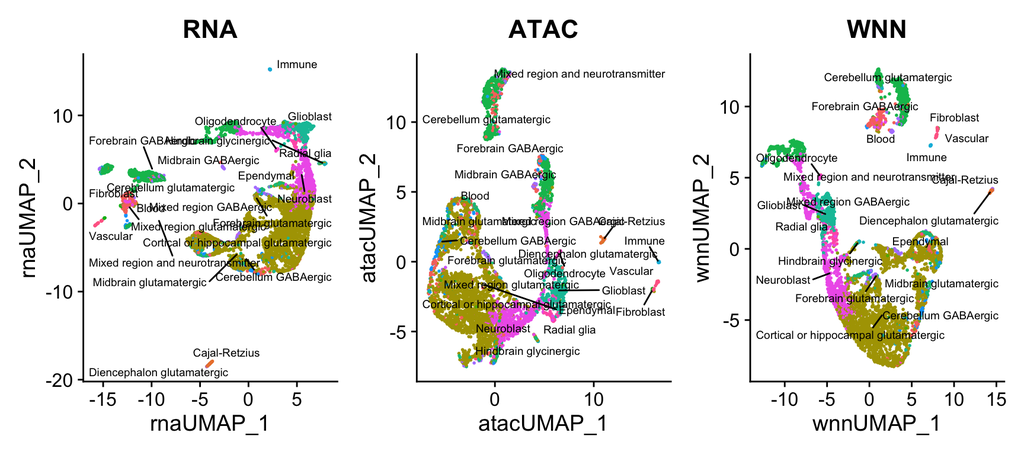

```r
p1 <- DimPlot(e18, reduction = "umap.rna",  group.by = "label.savercat",
    label = TRUE, label.size = 2.5, repel = TRUE) +
    ggtitle("RNA")
p2 <- DimPlot(e18, reduction = "umap.atac",  group.by = "label.savercat",
    label = TRUE, label.size = 2.5, repel = TRUE) +
    ggtitle("ATAC")
p3 <- DimPlot(e18, reduction = "wnn.umap", group.by = "label.savercat",
    label = TRUE, label.size = 2.5, repel = TRUE) +
    ggtitle("WNN")
p1 + p2 + p3 & NoLegend() & theme(plot.title = element_text(hjust = 0.5))
```

## 3.4 Filtering cells based on cell labels

Cell type labels can be used to filter the single cell data, which can, in turn, increase signal-to-noise ratio. We note that this procedure is inevitably subjective and that it is advisable to experiment with different filtering strategies. We merely illustrate an example case below, in which our basic goals are as follows.

- keep cells with biologically reasonable cell labels
- remove cells that belong to cell types with a small number of cells

We first examine the number of cells of each cell type.

```r
sort(table(e18$label.savercat), decreasing = TRUE)
```

```
#>
#> Cortical or hippocampal glutamatergic                   Forebrain GABAergic
#>                                  2333                                   708
#>                            Neuroblast                             Glioblast
#>                                   695                                   329
#>                                 Blood               Forebrain glutamatergic
#>                                   244                                   137
#>                Mixed region GABAergic                Midbrain glutamatergic
#>                                    91                                    86
#>                           Radial glia                         Cajal-Retzius
#>                                    65                                    38
#>                              Vascular                       Oligodendrocyte
#>                                    33                                    29
#>                 Hindbrain glycinergic                                Immune
#>                                    28                                    18
#>                            Fibroblast                             Ependymal
#>                                    12                                    10
#>                    Midbrain GABAergic                  Cerebellum GABAergic
#>                                    10                                     7
#>            Diencephalon glutamatergic              Cerebellum glutamatergic
#>                                     3                                     2
#>     Mixed region and neurotransmitter            Mixed region glutamatergic
#>                                     2                                     1
```

Based on the above information as well as existing biological knowledge, we focus on the seven cell types, “Cajal-Retzius”, “Cortical or hippocampal glutamatergic”, “Forebrain GABAergic”, “Glioblast”, “Neuroblast”, “Oligodendrocyte”, and “Radial glia”.

```r
# filter cells based on cell labels
celltypes.to.keep <- c("Cajal-Retzius",
    "Cortical or hippocampal glutamatergic",
  "Forebrain GABAergic", "Glioblast",
  "Neuroblast", "Oligodendrocyte", "Radial glia")
keep <- which(e18$label.savercat %in% celltypes.to.keep)
e18 <- subset(e18, cells = keep)
e18$celltype <- e18$label.savercat
e18$label.savercat <- NULL
```

For simplicity, we rename “Cortical or hippocampal glutamatergic” and “Forebrain GABAergic” as “Glutamatergic” and “GABAergic”, respectively.

```r
e18$celltype[e18$celltype == "Cortical or hippocampal glutamatergic"] <- "Glutamatergic"
e18$celltype[e18$celltype == "Forebrain GABAergic"] <- "GABAergic"
```

We convert the cell type data to factors and set the factor levels based on their developmental order (“Radial glia”, “Neuroblast”, “GABAergic”, “Glutamatergic”, “Glioblast”, “Oligodendrocyte”, and “Cajal-Retzius”).

```r
levels.celltype  <- c(
    "Radial glia", "Neuroblast",
    "GABAergic", "Glutamatergic",
    "Glioblast", "Oligodendrocyte",
    "Cajal-Retzius"
)
e18$celltype <- factor(e18$celltype, levels = levels.celltype)
```

## 3.5 Filtering cells based on sequencing depths

We then remove cells with low sequencing coverage or those with high proportions of mitochondrial reads, the latter of which is indicative of dying cells.

```r
e18 <- subset(
  x = e18,
  subset = nCount_ATAC < 1e5 &
    nCount_ATAC > 1e3 &
    nCount_RNA < 1e5 &
    nCount_RNA > 1e3 &
    percent.mt < 20
)
```

We then visualize the filtered data.

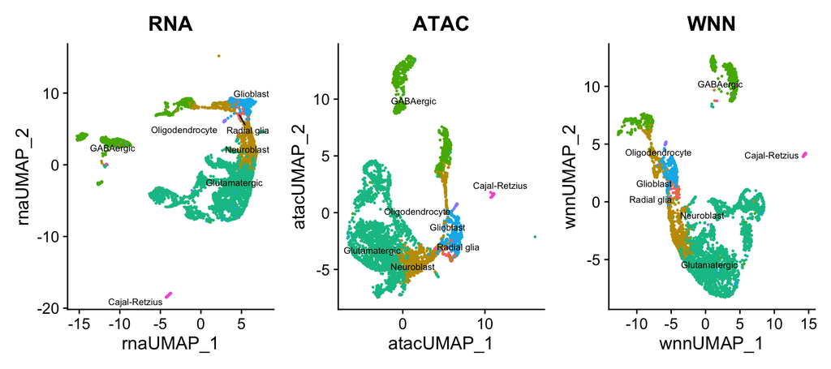

```r
p1 <- DimPlot(e18, reduction = "umap.rna", group.by = "celltype",
    label = TRUE, label.size = 2.5, repel = TRUE) +
    ggtitle("RNA")
p2 <- DimPlot(e18, reduction = "umap.atac", group.by = "celltype",
    label = TRUE, label.size = 2.5, repel = TRUE) +
    ggtitle("ATAC")
p3 <- DimPlot(e18, reduction = "wnn.umap", group.by = "celltype",
    label = TRUE, label.size = 2.5, repel = TRUE) +
    ggtitle("WNN")
p1 + p2 + p3 & NoLegend() & theme(plot.title = element_text(hjust = 0.5))
```

## 3.6 Run chromVAR

We next add TF motif information to the Seurat object according to the Signac tutorial [here](https://satijalab.org/signac/articles/motif_vignette.html).

```r
# create a motif object
pfm.set <- getMatrixSet(
    x = JASPAR2020,
    opts = list(species = 9606, all_versions = FALSE)) # human
```

In some cases, the TF motif information may not fully incorporate the existing knowledge in the literature. For example, in our analysis of the mouse embryonic brain data, we replace the motif for the OLIG2 TF with `CAGCTG`, which has been validated by previous genetic and biochemical studies (Küspert et al. 2011).

For this purpose, we first construct a PFM of the OLIG2 motif.

```r
PFM.OLIG2 <- PFMatrix(
    ID = "PFM.OLIG2",
    name = "OLIG2",
    strand = "+",
    bg = c(A = 0.25, C = 0.25, G = 0.25, T = 0.25),
  tags = list(
    species = "10090",
    tax_group = "vertebrates"),
    profileMatrix = matrix(
        c(0L,  1L, 0L,  0L,  0L,  0L, # A
        1L, 0L,  0L, 1L,  0L,  0L, # C
        0L,  0L,  1L,  0L, 0L,  1L, # G
        0L,  0L,  0L,  0L,  1L, 0L), # T
        byrow = TRUE, nrow = 4,
        dimnames=list(c("A", "C", "G", "T")))
)
```

The following code removes the original PFM of the OLIG2 motif from the PFM set and adds the custom PFM.

```r
pfm.set <- pfm.set[-which(sapply(pfm.set, function(x) x@name == "OLIG2"))]
pfm.set$PFM.OLIG2 <- PFM.OLIG2
```

The following code creates a motif matrix.

```r
motif.matrix <- CreateMotifMatrix(
  features = granges(e18),
  pwm = pfm.set,
  genome = "mm10",
  use.counts = FALSE
)
```

Once an optimal set of PFM is obtained, it can be added to the Seurat object using the following code.

```r
motif.object <- CreateMotifObject(data = motif.matrix, pwm = pfm.set)
e18 <- SetAssayData(e18, assay = "ATAC", slot = "motifs",
    new.data = motif.object)
e18 <- RunChromVAR(
  object = e18,
  genome = BSgenome.Mmusculus.UCSC.mm10
)
```

## 3.7 Creating objects required for model fitting

We then create objects containing information that is necessary for model fitting, namely, `transcripts.gr`, `peaks.gr`, `motifxTF`, and `peakxmotif`. The `transcripts.gr` object is a GRanges object from [the GenomicRanges package](https://bioconductor.org/packages/release/bioc/html/GenomicRanges.html) and contains chromosomal coordinates of annotated protein containing genes. The `peaks.gr` object is a GRanges object from the GenomicRanges package and contains chromosomal coordinates of the ATAC peak regions in the multiomic data. The `motifxTF` object is a matrix containing mapping between TFs and their binding motifs. The `peakxmotif` object is a binary sparse matrix containing indicators as to whether a given motif is present in a given ATAC peak region.

The `getObjectsForModelFit()` function creates a list object containing the four elements. The function keeps motifs only when genes encoding corresponding TFs are present in the RNA-seq data and ensures that the same set of genes is included in all objects.

```r
tripod.e18 <- getObjectsForModelFit(object = e18, chr = paste0("chr", 1:19))
```

Individual objects can be extracted using the following code.

```r
transcripts.gr <- tripod.e18$transcripts.gr
peaks.gr <- tripod.e18$peaks.gr
motifxTF <- tripod.e18$motifxTF
peakxmotif <- tripod.e18$peakxmotif
```

We also filter the Seurat object accordingly.

```r
e18 <- filterSeuratObject(object = e18, tripod.object = tripod.e18)
```

We note that our current implementation excludes cases where a TF corresponds to multiple motifs or vice versa. We plan to provide an option to include such degenerate cases in a future version of the package.

## 3.8 Reprocessing of the Seurat object

We then reprocess the filtered data using the `processSeuratObject()` function.

```r
e18 <- processSeuratObject(object = e18, dim.rna = 1:50, dim.atac = 2:50,
    verbose = FALSE)
```

The following code visualizes the data on recalculated graphs.

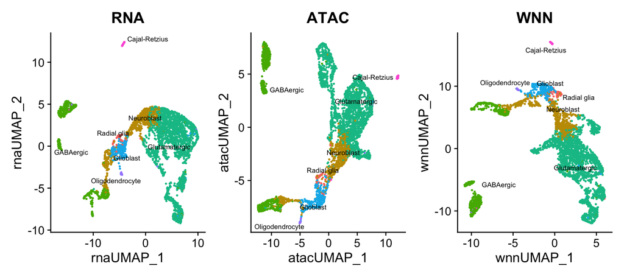

```r
p1 <- DimPlot(e18, reduction = "umap.rna",  group.by = "celltype",
    label = TRUE, label.size = 2.5, repel = TRUE) +
    ggtitle("RNA")
p2 <- DimPlot(e18, reduction = "umap.atac",  group.by = "celltype",
    label = TRUE, label.size = 2.5, repel = TRUE) +
    ggtitle("ATAC")
p3 <- DimPlot(e18, reduction = "wnn.umap", group.by = "celltype",
    label = TRUE, label.size = 2.5, repel = TRUE) +
    ggtitle("WNN")
p1 + p2 + p3 & NoLegend() & theme(plot.title = element_text(hjust = 0.5))
```

## 3.9 Partitioning single cells into metacells

To alleviate the issue of sparsity of the single cell data, we next partition the cells into clusters, which we call metacells. The models in the TRIPOD package are based on metacells, not single cells. Cells can be clustered based on either the ATAC or RNA modality. It is also possible to use the weighted nearest neighbor (WNN) method (Hao et al. 2021). For the mouse embryonic brain data, we use the RNA modality.

To obtain a set of metacells suited for model fitting, it is necessary to select an optimal resolution of clustering to ensure the following.

- a sufficient number of cells per metacell for resolving the sparsity issue
- a sufficient number of metacells to allow for model fitting

Our empirical approach is to select a resolution that gives 80 or more metacells, the majority of which contain 20 or more single cells. For this purpose, we first construct a shared nearest neighbor graph.

Based on the graph calculated in the previous section, we first perform clustering at several resolutions. The following code generates a data frame containing the resolutions, the number of resultant clusters, and the number of clusters with fewer than threshold number of single cells. The threshold is set to 20 cells.

```r
num.clusters <- optimizeResolution(
    object = e18,
    graph.name = "SCT_snn",
    assay.name = "SCT",
    resolutions = seq(10, 35, 5),
    min.num = 20
)
num.clusters
```

```
#>   resolution num_clusters num_below
#> 1         10           68         2
#> 2         15           85         3
#> 3         20          104         5
#> 4         25          124        10
#> 5         30          140        20
#> 6         35          161        43
```

Based on the above analysis, we select the resolution of 15.

```r
res <- 15
e18 <- getClusters(object = e18, graph.name = "SCT_snn",
        resolution = res, verbose = FALSE)
```

We now obtain matrices containing normalized RNA expression and chromatin accessibility per metacell using the `getMetacellMatrices` function. The function returns a list object containing metacell matrices for the RNA and ATAC modalities. We remove metacells with fewer than 20 single cells by setting the `min.num` to 20.

```r
metacell.e18 <- getMetacellMatrices(object = e18,
  cluster.name = "seurat_clusters",
    min.num = 20
)
```

Individual matrices can be extracted using the following code.

```r
metacell.rna <- metacell.e18$rna
metacell.peak <- metacell.e18$peak
```

We then remove corresponding single cells from the Seurat object. The `min.num` argument must to be set to the same as above.

```r
e18 <- removeSmallMetacells(object = e18, min.num = 20)
```

It is necessary to save the Seurat object (`e18`) for running [the TRIPOD vignette](http://htmlpreview.github.io/?https://github.com/yuchaojiang/TRIPOD/blob/main/vignettes/TRIPOD_e18.html) since the object is not included in the TRIPOD package.

```r
saveRDS(e18, "e18.rds")
```

## 3.10 Assigning cell types and colors for visualization

For visualization purposes, it is convenient to assign colors to cell types and create objects storing mapping between them. For this purpose, we use the `getColors()` function, which returns data frames containing mappings of colors to single cells, metacells, and cell types.

```r
e18$celltype=factor(e18$celltype)
color.e18 <- getColors(object = e18)
```

The following code extracts the mapping between the metacells and cell types as a character string. Note that the cell types are ordered by the metacell indices.

```r
metacell.celltype <- color.e18$metacell$celltype
metacell.celltype.col <- color.e18$metacell$color
```

## 3.11 Getting a list of target genes

We typically run model fitting for top-ranked highly variable genes (HVGs) identified by the `VariableFeatures()` function from the Seurat packages. The following code gives a ordered list of top 3000 HVGs.

```r
# obtain highly variable genes based on SCT
DefaultAssay(e18) <- "SCT"
hvg.e18 <- VariableFeatures(e18)
```

## 3.12 Save intermediate files

Here, we save the intermediate files that are needed for the next tutorial: [TRIPOD vignette for the 10x Genomics mouse embryonic brain data](http://htmlpreview.github.io/?https://github.com/yuchaojiang/TRIPOD/blob/main/vignettes/TRIPOD_e18.html).

```r
save(transcripts.gr, file = 'transcripts.gr.rda')
save(peaks.gr, file='peaks.gr.rda')
save(motifxTF, file='motifxTF.rda')
save(peakxmotif, file='peakxmotif.rda')
save(metacell.rna, file='metacell.rna.rda')
save(metacell.peak, file='metacell.peak.rda')
save(metacell.celltype, file='metacell.celltype.rda')
save(metacell.celltype.col, file='metacell.celltype.col.rda')
```

# References

Hao, Yuhan, Stephanie Hao, Erica Andersen-Nissen, William M. Mauck, Shiwei Zheng, Andrew Butler, Maddie J. Lee, et al. 2021. “Integrated Analysis of Multimodal Single-Cell Data.” *Cell* 184 (June): 3573–3587.e29. https://doi.org/10.1016/j.cell.2021.04.048.

Huang, Mo, Zhaojun Zhang, and Nancy R. Zhang. 2020. “Dimension Reduction and Denoising of Single-Cell RNA Sequencing Data in the Presence of Observed Confounding Variables,” August. https://doi.org/10.1101/2020.08.03.234765.

Küspert, Melanie, Alexander Hammer, Michael R. Bösl, and Michael Wegner. 2011. “Olig2 Regulates Sox10 Expression in Oligodendrocyte Precursors Through an Evolutionary Conserved Distal Enhancer.” *Nucleic Acids Research* 39 (March): 1280–93. https://doi.org/10.1093/nar/gkq951.

Stuart, Tim, Andrew Butler, Paul Hoffman, Christoph Hafemeister, Efthymia Papalexi, William M. Mauck, Yuhan Hao, Marlon Stoeckius, Peter Smibert, and Rahul Satija. 2019. “Comprehensive Integration of Single-Cell Data.” *Cell* 177 (June): 1888–1902.e21. https://doi.org/10.1016/j.cell.2019.05.031.